# R Notebook

# Exercise 10

```r
library(ISLR)

# Looking over data
Weekly
```

|  | Year | Lag1 | Lag2 | Lag3 | Lag4 | Lag5 | Volume | Today | Direction |
| --- | --- | --- | --- | --- | --- | --- | --- | --- | --- |
| 1 | 1990 | 0.816 | 1.572 | -3.936 | -0.229 | -3.484 | 0.1549760 | -0.270 | Down |
| 2 | 1990 | -0.270 | 0.816 | 1.572 | -3.936 | -0.229 | 0.1485740 | -2.576 | Down |
| 3 | 1990 | -2.576 | -0.270 | 0.816 | 1.572 | -3.936 | 0.1598375 | 3.514 | Up |
| 4 | 1990 | 3.514 | -2.576 | -0.270 | 0.816 | 1.572 | 0.1616300 | 0.712 | Up |
| 5 | 1990 | 0.712 | 3.514 | -2.576 | -0.270 | 0.816 | 0.1537280 | 1.178 | Up |
| 6 | 1990 | 1.178 | 0.712 | 3.514 | -2.576 | -0.270 | 0.1544440 | -1.372 | Down |
| 7 | 1990 | -1.372 | 1.178 | 0.712 | 3.514 | -2.576 | 0.1517220 | 0.807 | Up |
| 8 | 1990 | 0.807 | -1.372 | 1.178 | 0.712 | 3.514 | 0.1323100 | 0.041 | Up |
| 9 | 1990 | 0.041 | 0.807 | -1.372 | 1.178 | 0.712 | 0.1439720 | 1.253 | Up |
| 10 | 1990 | 1.253 | 0.041 | 0.807 | -1.372 | 1.178 | 0.1336350 | -2.678 | Down |

[output cut: 990 more lines]

```r
NA
```

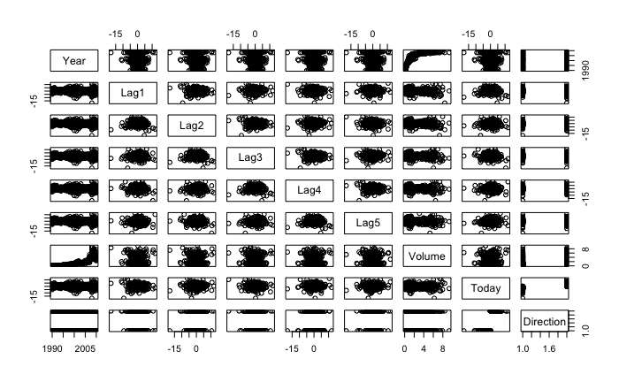

```r
pairs(Weekly)
```

```r
cor(Weekly[1:8],)
```

```
              Year         Lag1        Lag2        Lag3         Lag4         Lag5      Volume        Today
Year    1.00000000 -0.032289274 -0.03339001 -0.03000649 -0.031127923 -0.030519101  0.84194162 -0.032459894
Lag1   -0.03228927  1.000000000 -0.07485305  0.05863568 -0.071273876 -0.008183096 -0.06495131 -0.075031842
Lag2   -0.03339001 -0.074853051  1.00000000 -0.07572091  0.058381535 -0.072499482 -0.08551314  0.059166717
Lag3   -0.03000649  0.058635682 -0.07572091  1.00000000 -0.075395865  0.060657175 -0.06928771 -0.071243639
Lag4   -0.03112792 -0.071273876  0.05838153 -0.07539587  1.000000000 -0.075675027 -0.06107462 -0.007825873
Lag5   -0.03051910 -0.008183096 -0.07249948  0.06065717 -0.075675027  1.000000000 -0.05851741  0.011012698
Volume  0.84194162 -0.064951313 -0.08551314 -0.06928771 -0.061074617 -0.058517414  1.00000000 -0.033077783
Today  -0.03245989 -0.075031842  0.05916672 -0.07124364 -0.007825873  0.011012698 -0.03307778  1.000000000
```

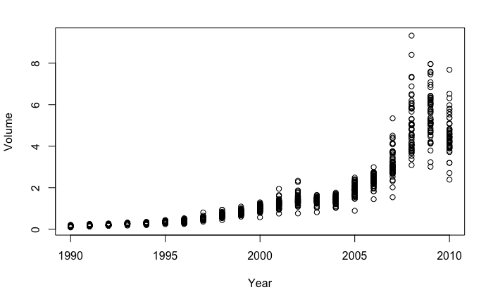

```r
attach(Weekly)
plot(Year, Volume)
```

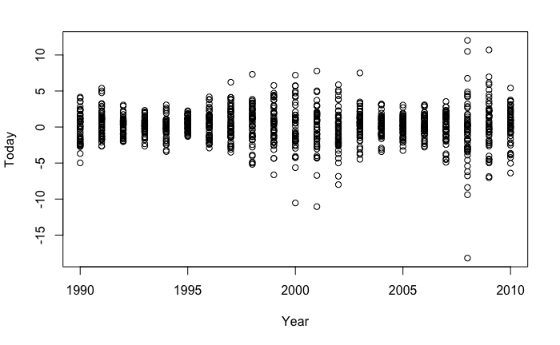

```r
plot(Year, Today)
```

### 10a

We see a positive relationship between year and volume. For other pairs there does not appear to be a relationship (other than today and direction)

### 10b

```r
logistic_regression <- glm(Direction ~ Lag1 + Lag2 + Lag3 + Lag4 + Lag5 + Volume, data = Weekly, family = binomial)
summary(logistic_regression)
```

```
Call:
glm(formula = Direction ~ Lag1 + Lag2 + Lag3 + Lag4 + Lag5 +
    Volume, family = binomial, data = Weekly)

Deviance Residuals:
    Min       1Q   Median       3Q      Max
-1.6949  -1.2565   0.9913   1.0849   1.4579

Coefficients:
            Estimate Std. Error z value Pr(>|z|)
(Intercept)  0.26686    0.08593   3.106   0.0019 **
Lag1        -0.04127    0.02641  -1.563   0.1181
Lag2         0.05844    0.02686   2.175   0.0296 *
Lag3        -0.01606    0.02666  -0.602   0.5469
Lag4        -0.02779    0.02646  -1.050   0.2937
Lag5        -0.01447    0.02638  -0.549   0.5833
Volume      -0.02274    0.03690  -0.616   0.5377
---
Signif. codes:  0 ‘***’ 0.001 ‘**’ 0.01 ‘*’ 0.05 ‘.’ 0.1 ‘ ’ 1

(Dispersion parameter for binomial family taken to be 1)

    Null deviance: 1496.2  on 1088  degrees of freedom
Residual deviance: 1486.4  on 1082  degrees of freedom
AIC: 1500.4

Number of Fisher Scoring iterations: 4
```

Lag 2 has a p-value of 0.0296, it is statistically significant

Just to plot it out

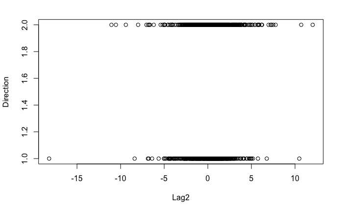

```r
plot(Lag2, Direction)
```

### 10c

Confusion matrix:

```r
weekly_probs <- predict(logistic_regression, type = "response")
weekly_pred <- rep("Down", nrow(Weekly))
contrasts(Direction)
```

```
     Up
Down  0
Up    1
```

```r
weekly_pred[weekly_probs > 0.5] <- "Up"
table(weekly_pred, Direction)
```

```
           Direction
weekly_pred Down  Up
       Down   54  48
       Up    430 557
```

```r
print(paste("Overall accuracy", as.character((54 + 557) / (54 + 48 + 430 + 557))))
```

```
[1] "Overall accuracy 0.561065197428834"
```

```r
print(paste("Accuracy of \'Down\' predictions", as.character(54 / (54 + 48))))
```

```
[1] "Accuracy of 'Down' predictions 0.529411764705882"
```

```r
print(paste("Accuracy of \'Up\' predictions", as.character(557 / (557 + 430))))
```

```
[1] "Accuracy of 'Up' predictions 0.564336372847011"
```

```r
print(paste("Accuracy given \'Up\' is true value", as.character(557 / (557 + 48))))
```

```
[1] "Accuracy given 'Up' is true value 0.920661157024793"
```

```r
print(paste("Accuracy given \'Down\' is true value", as.character(54 / (430 + 54))))
```

```
[1] "Accuracy given 'Down' is true value 0.111570247933884"
```

```r
print(paste("Proportion of the time \'Up\' is predicted", as.character((430 + 557) / (54 + 430 + 48 + 557))))
```

```
[1] "Proportion of the time 'Up' is predicted 0.90633608815427"
```

```r
print(paste("Prior probability of \'Up\' (baseline)", as.character((48 + 557) / (54 + 430 + 48 + 557))))
```

```
[1] "Prior probability of 'Up' (baseline) 0.555555555555556"
```

We see overall accuracy of 56%. Of the times ‘Down’ is predicted, the prediction is correct ~53% of the time. Of the times ‘Up’ is predicted, the prediction is correct about ~56.4% of the time. When ‘Up’ is the true value for the response, the prediction has ~92% accuracy. When ‘Down’ is the true value for the response, the prediction has ~11.1% accuracy. This is because the model predicts ‘Up’ ~90.6% of the time

### 10d

```r
train <- Year <= 2008
direction_test <- Direction[!train]
logistic_regression2 <- glm(Direction ~ Lag2, data = Weekly, family = binomial, subset = train)
summary(logistic_regression2)
```

```
Call:
glm(formula = Direction ~ Lag2, family = binomial, data = Weekly,
    subset = train)

Deviance Residuals:
   Min      1Q  Median      3Q     Max
-1.536  -1.264   1.021   1.091   1.368

Coefficients:
            Estimate Std. Error z value Pr(>|z|)
(Intercept)  0.20326    0.06428   3.162  0.00157 **
Lag2         0.05810    0.02870   2.024  0.04298 *
---
Signif. codes:  0 ‘***’ 0.001 ‘**’ 0.01 ‘*’ 0.05 ‘.’ 0.1 ‘ ’ 1

(Dispersion parameter for binomial family taken to be 1)

    Null deviance: 1354.7  on 984  degrees of freedom
Residual deviance: 1350.5  on 983  degrees of freedom
AIC: 1354.5

Number of Fisher Scoring iterations: 4
```

```r
weekly_probs2 <- predict(logistic_regression2,
                         Weekly[!train,],type = "response")
weekly_pred2 <- rep("Down", length(direction_test))
weekly_pred2[weekly_probs2 > 0.5] <- "Up"
table(weekly_pred2, direction_test)
```

```
            direction_test
weekly_pred2 Down Up
        Down    9  5
        Up     34 56
```

```r
print(paste("Overall pred accuracy:", as.character((9+56)/(9+5+34+56))))
```

```
[1] "Overall pred accuracy: 0.625"
```

Overall prediction accuracy: 62.5%

### 10e

```r
library(MASS)
lda_weekly <- lda(Direction ~ Lag2, data = Weekly, subset = train)
lda_weekly_pred <- predict(lda_weekly,
                         Weekly[!train,])
lda_tbl <- table(lda_weekly_pred$class, direction_test)
lda_tbl
```

```
      direction_test
       Down Up
  Down    9  5
  Up     34 56
```

```r
paste("Overall accuracy:", as.character((lda_tbl[1] + lda_tbl[4]) /
                                          (sum(lda_tbl[1:4]))))
```

```
[1] "Overall accuracy: 0.625"
```

### 10f

```r
qda_weekly <- qda(Direction ~ Lag2, data = Weekly, subset = train)
qda_weekly_pred <- predict(qda_weekly,
                         Weekly[!train,])
qda_tbl <- table(qda_weekly_pred$class, direction_test)
qda_tbl
```

```
      direction_test
       Down Up
  Down    0  0
  Up     43 61
```

```r
paste("Overall accuracy:", as.character((qda_tbl[1] + qda_tbl[4]) /
                                          (sum(qda_tbl[1:4]))))
```

```
[1] "Overall accuracy: 0.586538461538462"
```

### 10g

```r
tbl_accuracy <- function(tbl) {
  paste("Overall accuracy:", as.character((tbl[1] + tbl[4]) /
                                          (sum(tbl[1:4]))))
}

library(class)

standardized_lag2 <- scale(Lag2)
train_x <- standardized_lag2[train,]
test_x <- standardized_lag2[!train,]
train_y <- Direction[train]
test_y <- Direction[!train]

dim(train_x) <- c(length(train_x),1)
dim(test_x) <- c(length(test_x),1)
set.seed(1)
weekly_knn <- knn(train_x, test_x, train_y, k = 1)

knn_tbl <- table(weekly_knn, direction_test)
print(knn_tbl)
```

```
          direction_test
weekly_knn Down Up
      Down   21 31
      Up     22 30
```

```r
print(tbl_accuracy(knn_tbl))
```

```
[1] "Overall accuracy: 0.490384615384615"
```

### 10h

LDA and logistic regression appear to give the best results with a testing accuracy of 62.5%

### 10l

doing square of Lag2 for LDA

```r
library(magrittr)
lda_weekly <- lda(Direction ~ I(Lag2^2), data = Weekly, subset = train)
lda_weekly_pred <- predict(lda_weekly,
                         Weekly[!train,])
lda_tbl <- table(lda_weekly_pred$class, direction_test)
print(lda_tbl)
```

```
      direction_test
       Down Up
  Down    0  0
  Up     43 61
```

```r
tbl_accuracy(lda_tbl) %>% print
```

```
[1] "Overall accuracy: 0.586538461538462"
```

Combo of square and regular Lag2

```r
lda_weekly <- lda(Direction ~ Lag2 + I(Lag2^2), data = Weekly, subset = train)
lda_weekly_pred <- predict(lda_weekly,
                         Weekly[!train,])
lda_tbl <- table(lda_weekly_pred$class, direction_test)
print(lda_tbl)
```

```
      direction_test
       Down Up
  Down    7  4
  Up     36 57
```

```r
tbl_accuracy(lda_tbl) %>% print
```

```
[1] "Overall accuracy: 0.615384615384615"
```

Still not as good as the 62.5%

Trying 3NN

```r
set.seed(1)
library(class)

standardized_lag2 <- scale(Lag2)
train_x <- standardized_lag2[train,]
test_x <- standardized_lag2[!train,]
train_y <- Direction[train]
test_y <- Direction[!train]

dim(train_x) <- c(length(train_x),1)
dim(test_x) <- c(length(test_x),1)
set.seed(1)
weekly_knn <- knn(train_x, test_x, train_y, k = 3)

knn_tbl <- table(weekly_knn, direction_test)
print(knn_tbl)
```

```
          direction_test
weekly_knn Down Up
      Down   16 20
      Up     27 41
```

```r
print(tbl_accuracy(knn_tbl))
```

```
[1] "Overall accuracy: 0.548076923076923"
```

Plotting accuracy with movement of k

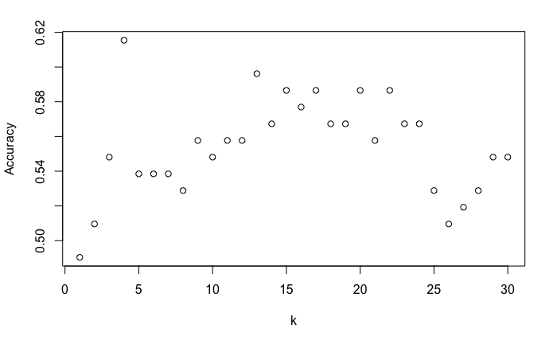

```r
tbl_accuracy2 <- function(tbl) {
  (tbl[1] + tbl[4]) / (sum(tbl[1:4]))
}

k_vals <- 1:30
accuracies <- c()
for (k in k_vals) {
  standardized_lag2 <- scale(Lag2)
  train_x <- standardized_lag2[train,]
  test_x <- standardized_lag2[!train,]
  train_y <- Direction[train]
  test_y <- Direction[!train]

  dim(train_x) <- c(length(train_x),1)
  dim(test_x) <- c(length(test_x),1)
  set.seed(1)
  weekly_knn <- knn(train_x, test_x, train_y, k = k)

  knn_tbl <- table(weekly_knn, direction_test)
  accuracies <- c(accuracies, tbl_accuracy2(knn_tbl))
}
plot(k_vals, accuracies, xlab = "k", ylab = "Accuracy")
```

let’s try k = 4

```r
set.seed(1)
library(class)

standardized_lag2 <- scale(Lag2)
train_x <- standardized_lag2[train,]
test_x <- standardized_lag2[!train,]
train_y <- Direction[train]
test_y <- Direction[!train]

dim(train_x) <- c(length(train_x),1)
dim(test_x) <- c(length(test_x),1)
set.seed(1)
weekly_knn <- knn(train_x, test_x, train_y, k = 4)

knn_tbl <- table(weekly_knn, direction_test)
print(knn_tbl)
```

```
          direction_test
weekly_knn Down Up
      Down   20 17
      Up     23 44
```

```r
print(tbl_accuracy(knn_tbl))
```

```
[1] "Overall accuracy: 0.615384615384615"
```

So 4NN gets us a 61.5% test accuracy, about 1% worse than LDA

LDA with Lag1^2 and Lag2

```r
lda_weekly <- lda(Direction ~ Lag2 + I(Lag1^2), data = Weekly, subset = train)
lda_weekly_pred <- predict(lda_weekly,
                         Weekly[!train,])
lda_tbl <- table(lda_weekly_pred$class, direction_test)
print(lda_tbl)
```

```
      direction_test
       Down Up
  Down    8  2
  Up     35 59
```

```r
tbl_accuracy(lda_tbl) %>% print
```

```
[1] "Overall accuracy: 0.644230769230769"
```

So LDA with Lag2 and Lag1^2 gives 64.4% accuracy, the best so far

```r
lda_weekly <- lda(Direction ~ Lag2 + Lag4:Lag3, data = Weekly, subset = train)
lda_weekly_pred <- predict(lda_weekly,
                         Weekly[!train,])
lda_tbl <- table(lda_weekly_pred$class, direction_test)
print(lda_tbl)
```

```
      direction_test
       Down Up
  Down   10  3
  Up     33 58
```

```r
tbl_accuracy(lda_tbl) %>% print
```

```
[1] "Overall accuracy: 0.653846153846154"
```

So here the combo of Lag2 and interaction of Lag4 and Lag3 gives ~65.4%

# Exercise 11

### 11a

```r
attach(Auto)
mpg01 <- mpg > median(mpg)
Auto1 <- cbind(Auto, mpg01)
```

### 11b

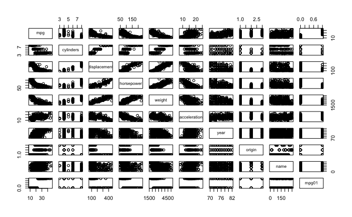

```r
pairs(Auto1)
```

```r
cor(Auto1[-9])
```

```
                    mpg  cylinders displacement horsepower     weight acceleration       year     origin      mpg01
mpg           1.0000000 -0.7776175   -0.8051269 -0.7784268 -0.8322442    0.4233285  0.5805410  0.5652088  0.8369392
cylinders    -0.7776175  1.0000000    0.9508233  0.8429834  0.8975273   -0.5046834 -0.3456474 -0.5689316 -0.7591939
displacement -0.8051269  0.9508233    1.0000000  0.8972570  0.9329944   -0.5438005 -0.3698552 -0.6145351 -0.7534766
horsepower   -0.7784268  0.8429834    0.8972570  1.0000000  0.8645377   -0.6891955 -0.4163615 -0.4551715 -0.6670526
weight       -0.8322442  0.8975273    0.9329944  0.8645377  1.0000000   -0.4168392 -0.3091199 -0.5850054 -0.7577566
acceleration  0.4233285 -0.5046834   -0.5438005 -0.6891955 -0.4168392    1.0000000  0.2903161  0.2127458  0.3468215
year          0.5805410 -0.3456474   -0.3698552 -0.4163615 -0.3091199    0.2903161  1.0000000  0.1815277  0.4299042
origin        0.5652088 -0.5689316   -0.6145351 -0.4551715 -0.5850054    0.2127458  0.1815277  1.0000000  0.5136984
mpg01         0.8369392 -0.7591939   -0.7534766 -0.6670526 -0.7577566    0.3468215  0.4299042  0.5136984  1.0000000
```

### 11c

```r
n_sample <- nrow(Auto1)
test_size <- n_sample / 4
test_filter <- rep(F, n_sample)
test_filter[1:test_size] <- T

test_set <- Auto1[test_filter,]
train_set <- Auto1[!test_filter,]

test_response <- Auto1$mpg01[test_filter]
train_response <- Auto1$mpg01[!test_filter]

nrow(test_set)
```

```
[1] 98
```

```r
nrow(train_set)
```

```
[1] 294
```

### 11d (LDA)

```r
lda_auto1 <- lda(mpg01 ~ cylinders + displacement + horsepower, data = Auto1, subset = !test_filter)
lda_auto1_pred <- predict(lda_auto1, test_set)
lda_auto1_tbl <- table(lda_auto1_pred$class, test_response)
print(lda_auto1_tbl)
```

```
       test_response
        FALSE TRUE
  FALSE    64    0
  TRUE      8   26
```

```r
tbl_accuracy(lda_auto1_tbl) %>% print
```

```
[1] "Overall accuracy: 0.918367346938776"
```

So test error rate is about 8.16%

### 11e (QDA)

```r
qda_auto1 <- qda(mpg01 ~ cylinders + displacement + horsepower, data = Auto1, subset = !test_filter)
qda_auto1_pred <- predict(qda_auto1, test_set)
qda_auto1_tbl <- table(qda_auto1_pred$class, test_response)
qda_auto1_tbl
```

```
       test_response
        FALSE TRUE
  FALSE    64    0
  TRUE      8   26
```

```r
tbl_accuracy(qda_auto1_tbl) %>% print
```

```
[1] "Overall accuracy: 0.918367346938776"
```

So test error rate is about 8.16%

### 11f (logistic regression)

```r
lr_auto1 <- glm(mpg01 ~ cylinders + displacement + horsepower, data = Auto1, family = binomial, subset = !test_filter)

lr_auto1_probs <- predict(lr_auto1, test_set)
lr_auto1_pred <- rep("Down", length(test_set))
lr_auto1_pred[lr_auto1_probs > 0.5] <- "Up"

lr_auto1_tbl <- table(lr_auto1_pred, test_response)
lr_auto1_tbl
```

```
             test_response
lr_auto1_pred FALSE TRUE
         Down    10    0
         Up       7   25
```

```r
tbl_accuracy(lr_auto1_tbl) %>% print
```

```
[1] "Overall accuracy: 0.833333333333333"
```

Test error is about 16.6%

### 11g (KNN)

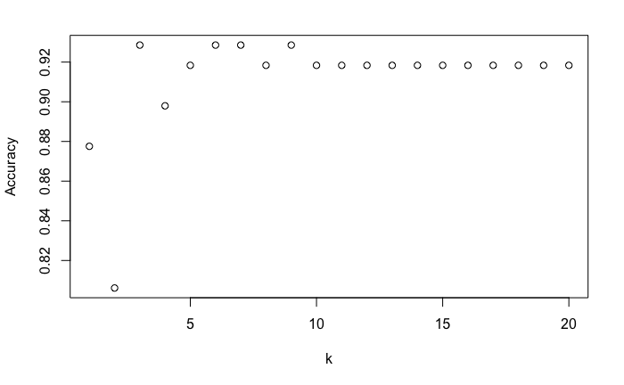

```r
tbl_accuracy2 <- function(tbl) {
  (tbl[1] + tbl[4]) / (sum(tbl[1:4]))
}

k_vals <- 1:20
accuracies <- c()

standard_features <- data.frame(cylinders = Auto1$cylinders,
                                displacement = Auto1$displacement,
                                horsepower = Auto1$horsepower)

standard_features$cylinders <- scale(standard_features$cylinders)
standard_features$displacement <- scale(standard_features$displacement)
standard_features$horsepower <- scale(standard_features$horsepower)

train_set <- standard_features[!test_filter,]
test_set <- standard_features[test_filter,]

train_response <- Auto1$mpg01[!test_filter]
test_response <- Auto1$mpg01[test_filter]

for (k in k_vals) {
  set.seed(1)
  temp_knn <- knn(train = train_set, test = test_set, cl = train_response, k = k)

  knn_tbl <- table(temp_knn,test_response)
  accuracies <- c(accuracies, tbl_accuracy2(knn_tbl))
}
plot(k_vals, accuracies, xlab = "k", ylab = "Accuracy")
```

```r
NA
NA
NA
```

Looks like k=3 is the best choice

```r
set.seed(1)
temp_knn <- knn(train = train_set, test = test_set, cl = train_response, k = 3)

knn_tbl <- table(temp_knn,test_response)
knn_tbl
```

```
        test_response
temp_knn FALSE TRUE
   FALSE    66    1
   TRUE      6   25
```

```r
tbl_accuracy(knn_tbl) %>% print()
```

```
[1] "Overall accuracy: 0.928571428571429"
```

This gives us a test error rate of 7.14%

# Exercise 12

### 12a

```r
Power <- function() {
  print(2^3)
}
```

### 12b

```r
Power2 <- function(x, a) {
  print(x^a)
}

Power2(3, 8)
```

```
[1] 6561
```

### 12c

```r
Power2(10, 3)
```

```
[1] 1000
```

```r
Power2(8, 17)
```

```
[1] 2.2518e+15
```

```r
Power2(131, 3)
```

```
[1] 2248091
```

### 12d, 12e

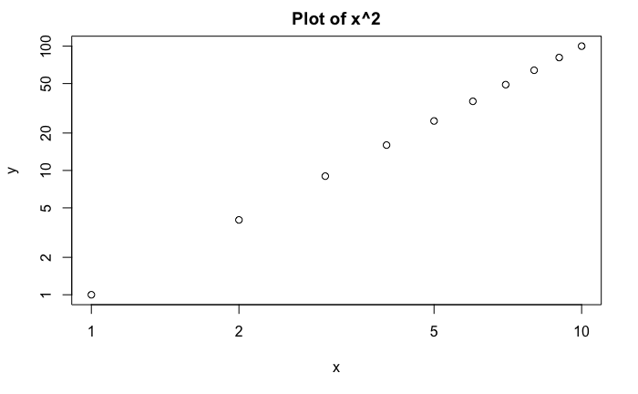

```r
Power3 <- function(x, a) {
  return(x^a)
}
plot(Power3(1:10, 2), xlab = "x", ylab = "y",
     main = "Plot of x^2", log="xy")
```

### 12f

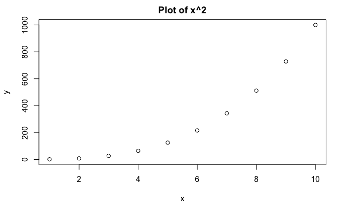

```r
PlotPower <- function(x, a) {
  plot(Power3(x, a), xlab = "x", ylab = "y",
     main = "Plot of x^2")
}
PlotPower(1:10, 3)
```

# Exercise 13

Predicting whether a given suburb has a crime rate above or below the median

```r
crime_med <- Boston$crim > median(Boston$crim)
Boston1 <- cbind(Boston, crime_med)
Boston1
```

|  | crim | zn | indus | chas | nox | rm | age | dis | rad | tax | ptratio | black | lstat | medv | crime_med |
| --- | --- | --- | --- | --- | --- | --- | --- | --- | --- | --- | --- | --- | --- | --- | --- |
| 1 | 0.00632 | 18.0 | 2.31 | 0 | 0.5380 | 6.575 | 65.2 | 4.0900 | 1 | 296 | 15.3 | 396.90 | 4.98 | 24.0 | FALSE |
| 2 | 0.02731 | 0.0 | 7.07 | 0 | 0.4690 | 6.421 | 78.9 | 4.9671 | 2 | 242 | 17.8 | 396.90 | 9.14 | 21.6 | FALSE |
| 3 | 0.02729 | 0.0 | 7.07 | 0 | 0.4690 | 7.185 | 61.1 | 4.9671 | 2 | 242 | 17.8 | 392.83 | 4.03 | 34.7 | FALSE |
| 4 | 0.03237 | 0.0 | 2.18 | 0 | 0.4580 | 6.998 | 45.8 | 6.0622 | 3 | 222 | 18.7 | 394.63 | 2.94 | 33.4 | FALSE |
| 5 | 0.06905 | 0.0 | 2.18 | 0 | 0.4580 | 7.147 | 54.2 | 6.0622 | 3 | 222 | 18.7 | 396.90 | 5.33 | 36.2 | FALSE |
| 6 | 0.02985 | 0.0 | 2.18 | 0 | 0.4580 | 6.430 | 58.7 | 6.0622 | 3 | 222 | 18.7 | 394.12 | 5.21 | 28.7 | FALSE |
| 7 | 0.08829 | 12.5 | 7.87 | 0 | 0.5240 | 6.012 | 66.6 | 5.5605 | 5 | 311 | 15.2 | 395.60 | 12.43 | 22.9 | FALSE |
| 8 | 0.14455 | 12.5 | 7.87 | 0 | 0.5240 | 6.172 | 96.1 | 5.9505 | 5 | 311 | 15.2 | 396.90 | 19.15 | 27.1 | FALSE |
| 9 | 0.21124 | 12.5 | 7.87 | 0 | 0.5240 | 5.631 | 100.0 | 6.0821 | 5 | 311 | 15.2 | 386.63 | 29.93 | 16.5 | FALSE |
| 10 | 0.17004 | 12.5 | 7.87 | 0 | 0.5240 | 6.004 | 85.9 | 6.5921 | 5 | 311 | 15.2 | 386.71 | 17.10 | 18.9 | FALSE |

[output cut: 496 more lines]

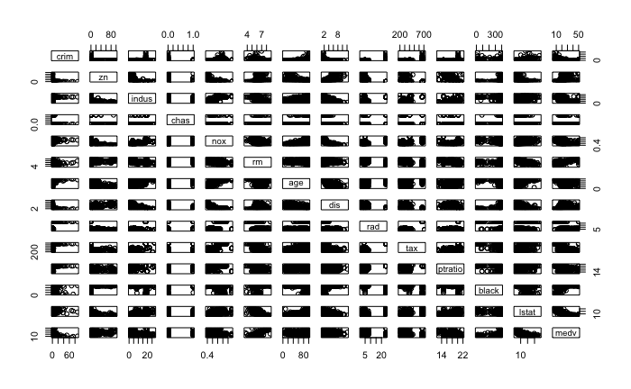

```r
pairs(Boston)
```

```r
cor(Boston1)
```

```
                 crim          zn       indus         chas         nox          rm         age         dis          rad         tax
crim       1.00000000 -0.20046922  0.40658341 -0.055891582  0.42097171 -0.21924670  0.35273425 -0.37967009  0.625505145  0.58276431
zn        -0.20046922  1.00000000 -0.53382819 -0.042696719 -0.51660371  0.31199059 -0.56953734  0.66440822 -0.311947826 -0.31456332
indus      0.40658341 -0.53382819  1.00000000  0.062938027  0.76365145 -0.39167585  0.64477851 -0.70802699  0.595129275  0.72076018
chas      -0.05589158 -0.04269672  0.06293803  1.000000000  0.09120281  0.09125123  0.08651777 -0.09917578 -0.007368241 -0.03558652
nox        0.42097171 -0.51660371  0.76365145  0.091202807  1.00000000 -0.30218819  0.73147010 -0.76923011  0.611440563  0.66802320
rm        -0.21924670  0.31199059 -0.39167585  0.091251225 -0.30218819  1.00000000 -0.24026493  0.20524621 -0.209846668 -0.29204783
age        0.35273425 -0.56953734  0.64477851  0.086517774  0.73147010 -0.24026493  1.00000000 -0.74788054  0.456022452  0.50645559
dis       -0.37967009  0.66440822 -0.70802699 -0.099175780 -0.76923011  0.20524621 -0.74788054  1.00000000 -0.494587930 -0.53443158
rad        0.62550515 -0.31194783  0.59512927 -0.007368241  0.61144056 -0.20984667  0.45602245 -0.49458793  1.000000000  0.91022819
tax        0.58276431 -0.31456332  0.72076018 -0.035586518  0.66802320 -0.29204783  0.50645559 -0.53443158  0.910228189  1.00000000
ptratio    0.28994558 -0.39167855  0.38324756 -0.121515174  0.18893268 -0.35550149  0.26151501 -0.23247054  0.464741179  0.46085304
black     -0.38506394  0.17552032 -0.35697654  0.048788485 -0.38005064  0.12806864 -0.27353398  0.29151167 -0.444412816 -0.44180801
lstat      0.45562148 -0.41299457  0.60379972 -0.053929298  0.59087892 -0.61380827  0.60233853 -0.49699583  0.488676335  0.54399341
medv      -0.38830461  0.36044534 -0.48372516  0.175260177 -0.42732077  0.69535995 -0.37695457  0.24992873 -0.381626231 -0.46853593
crime_med  0.40939545 -0.43615103  0.60326017  0.070096774  0.72323480 -0.15637178  0.61393992 -0.61634164  0.619786249  0.60874128
             ptratio       black      lstat       medv   crime_med
crim       0.2899456 -0.38506394  0.4556215 -0.3883046  0.40939545
zn        -0.3916785  0.17552032 -0.4129946  0.3604453 -0.43615103
indus      0.3832476 -0.35697654  0.6037997 -0.4837252  0.60326017
chas      -0.1215152  0.04878848 -0.0539293  0.1752602  0.07009677
nox        0.1889327 -0.38005064  0.5908789 -0.4273208  0.72323480
rm        -0.3555015  0.12806864 -0.6138083  0.6953599 -0.15637178
age        0.2615150 -0.27353398  0.6023385 -0.3769546  0.61393992
dis       -0.2324705  0.29151167 -0.4969958  0.2499287 -0.61634164
rad        0.4647412 -0.44441282  0.4886763 -0.3816262  0.61978625
tax        0.4608530 -0.44180801  0.5439934 -0.4685359  0.60874128
ptratio    1.0000000 -0.17738330  0.3740443 -0.5077867  0.25356836
black     -0.1773833  1.00000000 -0.3660869  0.3334608 -0.35121093
lstat      0.3740443 -0.36608690  1.0000000 -0.7376627  0.45326273
medv      -0.5077867  0.33346082 -0.7376627  1.0000000 -0.26301673
crime_med  0.2535684 -0.35121093  0.4532627 -0.2630167  1.00000000
```

Splitting into train and test sets

```r
# shuffling
Boston1[sample(1:nrow(Boston1)), ]
```

|  | crim | zn | indus | chas | nox | rm | age | dis | rad | tax | ptratio | black | lstat | medv | crime_med |
| --- | --- | --- | --- | --- | --- | --- | --- | --- | --- | --- | --- | --- | --- | --- | --- |
| 362 | 3.83684 | 0.0 | 18.10 | 0 | 0.7700 | 6.251 | 91.1 | 2.2955 | 24 | 666 | 20.2 | 350.65 | 14.19 | 19.9 | TRUE |
| 438 | 15.17720 | 0.0 | 18.10 | 0 | 0.7400 | 6.152 | 100.0 | 1.9142 | 24 | 666 | 20.2 | 9.32 | 26.45 | 8.7 | TRUE |
| 494 | 0.17331 | 0.0 | 9.69 | 0 | 0.5850 | 5.707 | 54.0 | 2.3817 | 6 | 391 | 19.2 | 396.90 | 12.01 | 21.8 | FALSE |
| 330 | 0.06724 | 0.0 | 3.24 | 0 | 0.4600 | 6.333 | 17.2 | 5.2146 | 4 | 430 | 16.9 | 375.21 | 7.34 | 22.6 | FALSE |
| 263 | 0.52014 | 20.0 | 3.97 | 0 | 0.6470 | 8.398 | 91.5 | 2.2885 | 5 | 264 | 13.0 | 386.86 | 5.91 | 48.8 | TRUE |
| 329 | 0.06617 | 0.0 | 3.24 | 0 | 0.4600 | 5.868 | 25.8 | 5.2146 | 4 | 430 | 16.9 | 382.44 | 9.97 | 19.3 | FALSE |
| 79 | 0.05646 | 0.0 | 12.83 | 0 | 0.4370 | 6.232 | 53.7 | 5.0141 | 5 | 398 | 18.7 | 386.40 | 12.34 | 21.2 | FALSE |
| 213 | 0.21719 | 0.0 | 10.59 | 1 | 0.4890 | 5.807 | 53.8 | 3.6526 | 4 | 277 | 18.6 | 390.94 | 16.03 | 22.4 | FALSE |
| 37 | 0.09744 | 0.0 | 5.96 | 0 | 0.4990 | 5.841 | 61.4 | 3.3779 | 5 | 279 | 19.2 | 377.56 | 11.41 | 20.0 | FALSE |
| 105 | 0.13960 | 0.0 | 8.56 | 0 | 0.5200 | 6.167 | 90.0 | 2.4210 | 5 | 384 | 20.9 | 392.69 | 12.33 | 20.1 | FALSE |

[output cut: 496 more lines]

```r
n_obs <- nrow(Boston1)
n_test <- n_obs / 2
test_filter <- rep(F, n_obs)
test_filter[1:n_test] <- T

train_x <- Boston1[!test_filter,]
train_y <- Boston1$crime_med[!test_filter]

test_x <- Boston1[test_filter,]
test_y <- Boston1$crime_med[test_filter]
```

Looks like indus, nox, age, dis, rad, tax have most correlation with crime_med ### Logistic regression

```r
lr_boston <- glm(crime_med ~ indus + nox + rad + tax + dis + age,
                 data = Boston1, family = binomial, subset = !test_filter)
summary(lr_boston)
```

```
Call:
glm(formula = crime_med ~ indus + nox + rad + tax + dis + age,
    family = binomial, data = Boston1, subset = !test_filter)

Deviance Residuals:
     Min        1Q    Median        3Q       Max
-1.42651  -0.18420   0.00718   0.02638   2.38786

Coefficients:
             Estimate Std. Error z value Pr(>|z|)
(Intercept) -15.22903    5.01015  -3.040  0.00237 **
indus         0.09602    0.15055   0.638  0.52361
nox          26.77785    8.23822   3.250  0.00115 **
rad           0.50643    0.21366   2.370  0.01777 *
tax          -0.01256    0.00742  -1.692  0.09064 .
dis           0.09472    0.28226   0.336  0.73720
age           0.01049    0.01835   0.572  0.56762
---
Signif. codes:  0 ‘***’ 0.001 ‘**’ 0.01 ‘*’ 0.05 ‘.’ 0.1 ‘ ’ 1

(Dispersion parameter for binomial family taken to be 1)

    Null deviance: 329.367  on 252  degrees of freedom
Residual deviance:  83.881  on 246  degrees of freedom
AIC: 97.881

Number of Fisher Scoring iterations: 10
```

```r
lr_boston_probs <- predict(lr_boston, test_x)
lr_boston_pred <- rep(F, n_test)
lr_boston_pred[lr_boston_probs > 0.5] <- T

lr_boston_tbl <- table(lr_boston_pred, test_y)
lr_boston_tbl
```

```
              test_y
lr_boston_pred FALSE TRUE
         FALSE   152   45
         TRUE     11   45
```

```r
tbl_accuracy(lr_boston_tbl) %>% print
```

```
[1] "Overall accuracy: 0.778656126482213"
```

Plotting different predictors against response to see if there is nonlinearity

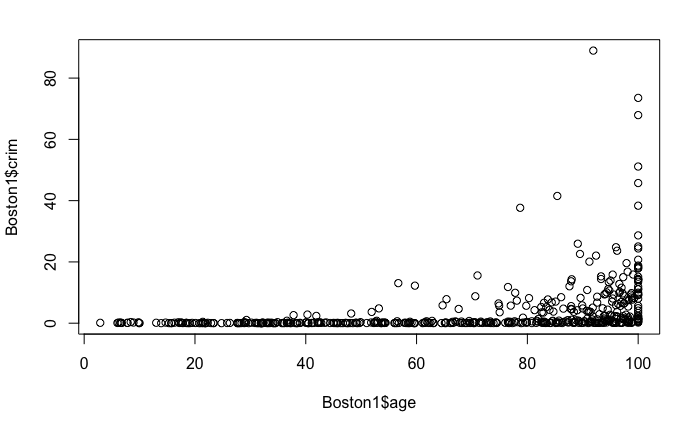

```r
plot(Boston1$age, Boston1$crim)
```

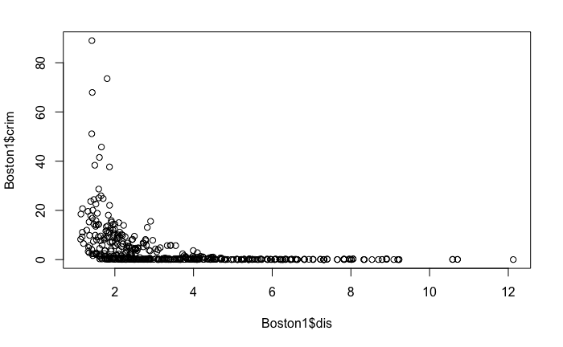

```r
plot(Boston1$dis, Boston1$crim)
```

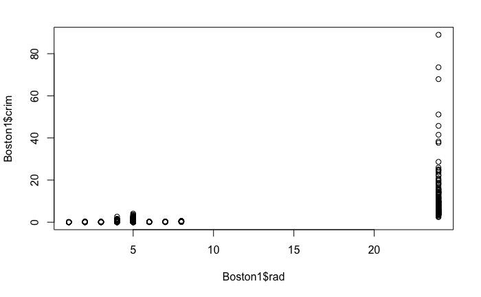

```r
plot(Boston1$rad, Boston1$crim)
```

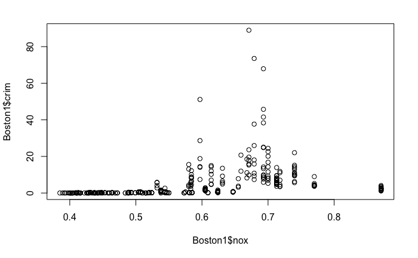

```r
plot(Boston1$nox, Boston1$crim)
```

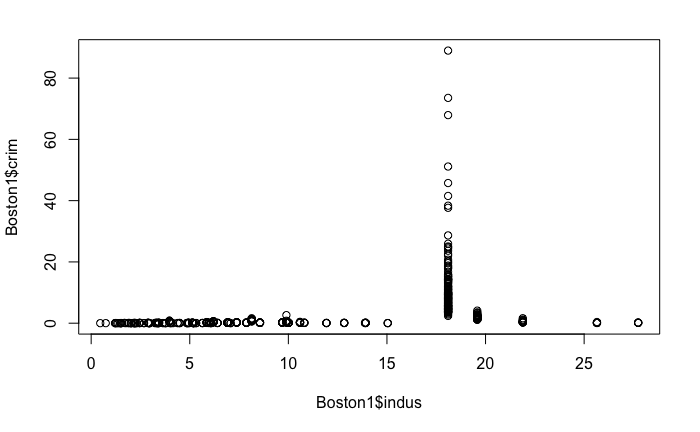

```r
plot(Boston1$indus, Boston1$crim)
```

Trying quadratic transforms for different parameters

```r
lr_boston <- glm(crime_med ~ indus + nox + rad + tax + dis + I(age^2),
                 data = Boston1, family = binomial, subset = !test_filter)
lr_boston_probs <- predict(lr_boston, test_x)
lr_boston_pred <- rep(F, n_test)
lr_boston_pred[lr_boston_probs > 0.5] <- T

lr_boston_tbl <- table(lr_boston_pred, test_y)
lr_boston_tbl
```

```
              test_y
lr_boston_pred FALSE TRUE
         FALSE   152   43
         TRUE     11   47
```

```r
tbl_accuracy(lr_boston_tbl) %>% print
```

```
[1] "Overall accuracy: 0.786561264822134"
```

```r
lr_boston <- glm(crime_med ~ indus + nox + rad + tax + I(dis^2) + age,
                 data = Boston1, family = binomial, subset = !test_filter)
lr_boston_probs <- predict(lr_boston, test_x)
lr_boston_pred <- rep(F, n_test)
lr_boston_pred[lr_boston_probs > 0.5] <- T

lr_boston_tbl <- table(lr_boston_pred, test_y)
lr_boston_tbl
```

```
              test_y
lr_boston_pred FALSE TRUE
         FALSE   152   45
         TRUE     11   45
```

```r
tbl_accuracy(lr_boston_tbl) %>% print
```

```
[1] "Overall accuracy: 0.778656126482213"
```

```r
lr_boston <- glm(crime_med ~ indus + I(nox^2) + rad + tax + dis + age,
                 data = Boston1, family = binomial, subset = !test_filter)
lr_boston_probs <- predict(lr_boston, test_x)
lr_boston_pred <- rep(F, n_test)
lr_boston_pred[lr_boston_probs > 0.5] <- T

lr_boston_tbl <- table(lr_boston_pred, test_y)
lr_boston_tbl
```

```
              test_y
lr_boston_pred FALSE TRUE
         FALSE   152   45
         TRUE     11   45
```

```r
tbl_accuracy(lr_boston_tbl) %>% print
```

```
[1] "Overall accuracy: 0.778656126482213"
```

```r
lr_boston <- glm(crime_med ~ indus + nox + rad + I(tax^2) + dis + age,
                 data = Boston1, family = binomial, subset = !test_filter)
lr_boston_probs <- predict(lr_boston, test_x)
lr_boston_pred <- rep(F, n_test)
lr_boston_pred[lr_boston_probs > 0.5] <- T

lr_boston_tbl <- table(lr_boston_pred, test_y)
lr_boston_tbl
```

```
              test_y
lr_boston_pred FALSE TRUE
         FALSE   152   29
         TRUE     11   61
```

```r
tbl_accuracy(lr_boston_tbl) %>% print
```

```
[1] "Overall accuracy: 0.841897233201581"
```

```r
lr_boston <- glm(crime_med ~ indus + nox + I(rad^2) + tax + dis + age,
                 data = Boston1, family = binomial, subset = !test_filter)
lr_boston_probs <- predict(lr_boston, test_x)
lr_boston_pred <- rep(F, n_test)
lr_boston_pred[lr_boston_probs > 0.5] <- T

lr_boston_tbl <- table(lr_boston_pred, test_y)
lr_boston_tbl
```

```
              test_y
lr_boston_pred FALSE TRUE
         FALSE   157   73
         TRUE      6   17
```

```r
tbl_accuracy(lr_boston_tbl) %>% print
```

```
[1] "Overall accuracy: 0.687747035573123"
```

```r
lr_boston <- glm(crime_med ~ I(indus^2) + nox + rad + tax + dis + age,
                 data = Boston1, family = binomial, subset = !test_filter)
lr_boston_probs <- predict(lr_boston, test_x)
lr_boston_pred <- rep(F, n_test)
lr_boston_pred[lr_boston_probs > 0.5] <- T

lr_boston_tbl <- table(lr_boston_pred, test_y)
lr_boston_tbl
```

```
              test_y
lr_boston_pred FALSE TRUE
         FALSE   163   69
         TRUE      0   21
```

```r
tbl_accuracy(lr_boston_tbl) %>% print
```

```
[1] "Overall accuracy: 0.727272727272727"
```

```r
lr_boston <- glm(crime_med ~ indus + nox + rad + I(tax^2) + dis + age + black + zn,
                 data = Boston1, family = binomial, subset = !test_filter)
lr_boston_probs <- predict(lr_boston, test_x)
lr_boston_pred <- rep(F, n_test)
lr_boston_pred[lr_boston_probs > 0.5] <- T

lr_boston_tbl <- table(lr_boston_pred, test_y)
lr_boston_tbl
```

```
              test_y
lr_boston_pred FALSE TRUE
         FALSE   147   17
         TRUE     16   73
```

```r
tbl_accuracy(lr_boston_tbl) %>% print
```

```
[1] "Overall accuracy: 0.869565217391304"
```

Best accuracy so far for logistic regression is ~87%

### LDA

```r
lda_boston <- lda(crime_med ~ indus + nox + rad + I(tax^2) + dis + age + black + zn, data = Boston1, subset = !test_filter)
lda_boston_pred <- predict(lda_boston, test_x)
lda_boston_tbl <- table(lda_boston_pred$class, test_y)
print(lda_boston_tbl)
```

```
       test_y
        FALSE TRUE
  FALSE   159   58
  TRUE      4   32
```

```r
tbl_accuracy(lda_boston_tbl) %>% print
```

```
[1] "Overall accuracy: 0.754940711462451"
```

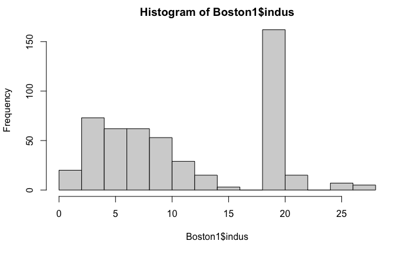

```r
hist(Boston1$indus)
```

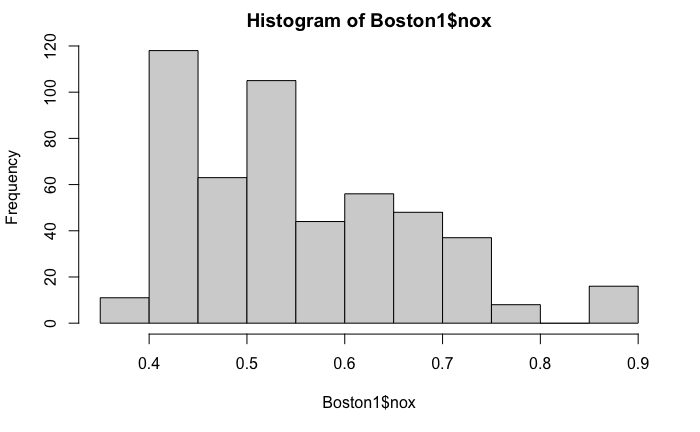

```r
hist(Boston1$nox)
```

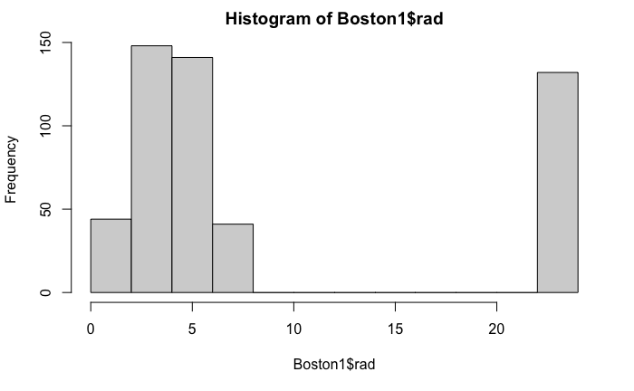

```r
hist(Boston1$rad)
```

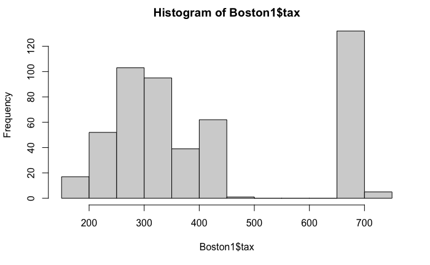

```r
hist(Boston1$tax)
```

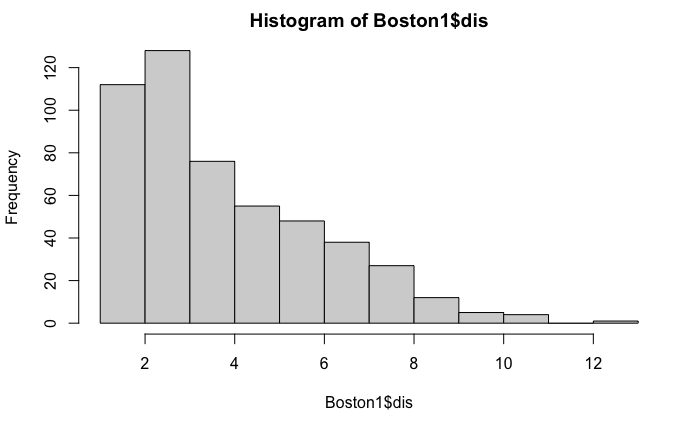

```r
hist(Boston1$dis)
```

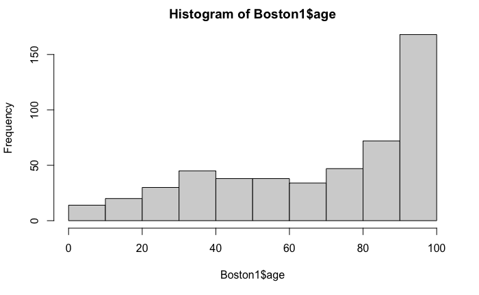

```r
hist(Boston1$age)
```

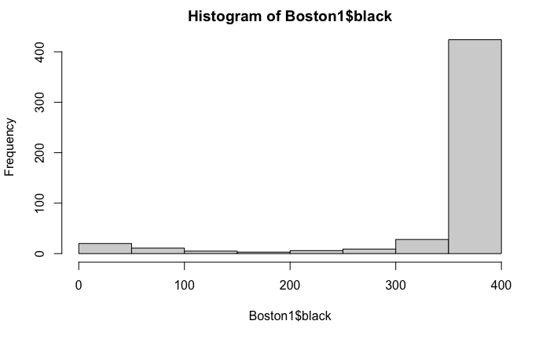

```r
hist(Boston1$black)
```

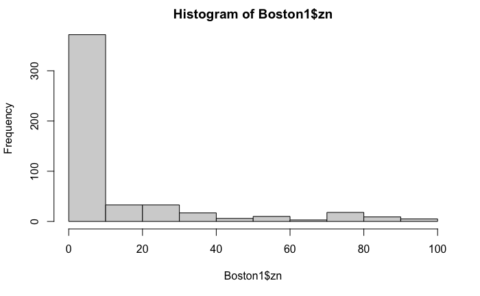

```r
hist(Boston1$zn)
```

### KNN

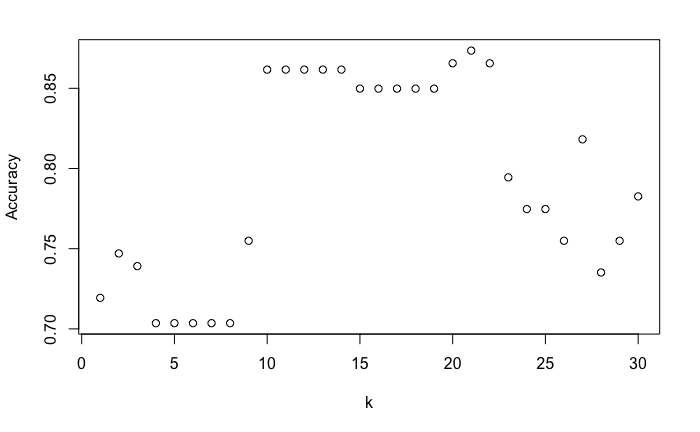

```r
k_vals <- 1:30
accuracies <- c()

Boston2 <- data.frame(
                      nox = Boston1$nox,
                      tax = Boston1$tax)

for (i in 1:length(Boston2)) {
  Boston2[i] <- Boston2[i] %>% scale
}

train_x <- Boston2[!test_filter,]
train_y <- Boston1$crime_med[!test_filter]
test_x <- Boston2[test_filter,]
test_y <- Boston1$crime_med[test_filter]

for (k in k_vals) {
  set.seed(1)
  temp_knn <- knn(train = train_x, test = test_x, cl = train_y, k = k)

  knn_tbl <- table(temp_knn, test_y)
  accuracies <- c(accuracies, tbl_accuracy2(knn_tbl))
}
plot(k_vals, accuracies, xlab = "k", ylab = "Accuracy")
```

So we see high accuracy at k = 21

```r
boston_21nn <- knn(train = train_x, test = test_x, cl = train_y, k = 21)
boston_21nn_tbl <- table(boston_21nn, test_y)
boston_21nn_tbl
```

```
           test_y
boston_21nn FALSE TRUE
      FALSE   134    5
      TRUE     29   85
```

```r
tbl_accuracy(boston_21nn_tbl) %>% print
```

```
[1] "Overall accuracy: 0.865612648221344"
```

So 21NN gets around ~86.6% accuracy